# EE550 Letters HW1

Erhan Can Ozcan - 2018702099

3/3/2019

# Discrete Time Hopfield Nueral Network Model

## Original Letters A,B,C,D and T

Firstly, all original letters in 8 by 8 grid can be seen below. While the white points on the 2D plots represent 1, black points do -1. These five samples are utilized in order to construct the T<sub>ij</sub> matrix. Note that since letters are in 8 by 8 grid, we have 64 neurons for each sample. Therefore, T<sub>ij</sub> matrix is 64*64

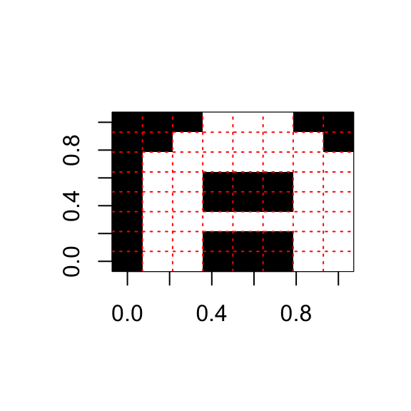

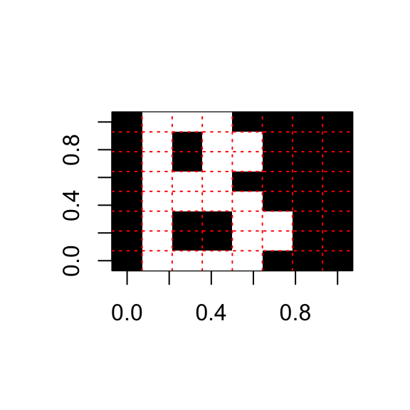

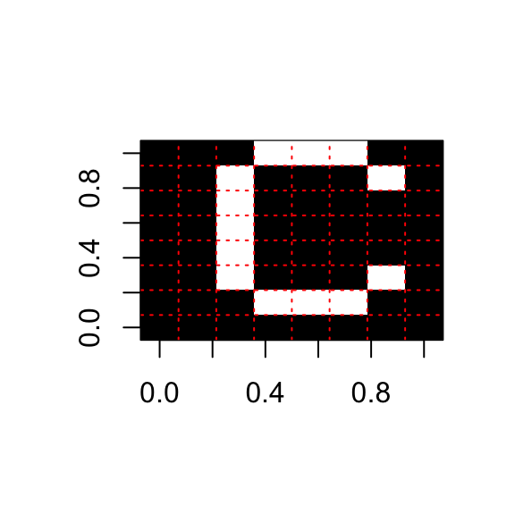

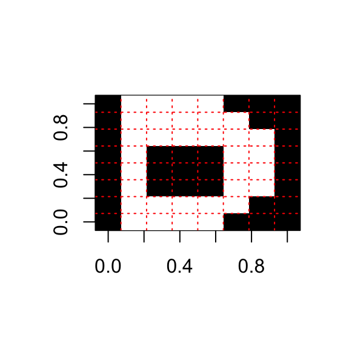

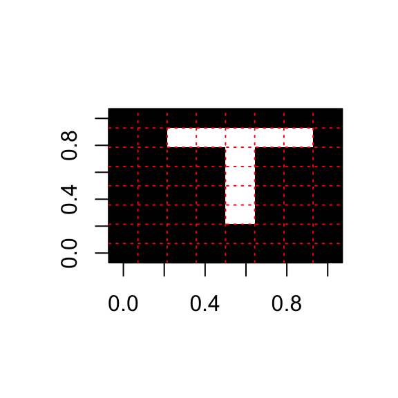

## Evaluation of Each Letter After Adding Normally Distributed Noise with Different Variance

While obtaining the initial noisy states, the procedures below are followed:

1. First of all, a normal random noise with mean=0 and a specified sigma is added to each neuron.
2. Secondly, if value of a neuron is larger than 0, it is assigned to 1. Otherwise, it is assigned to -1.

In this way, original letters are distorted. Distorted represantions of letters are labeled as **“Initial State with Added Noise”** in the given plots below.

Then, Discrete Time Hopfield Neural Network Model is applied to distorted pictures until convergence takes place.

All letters with various sigma values can be seen below.

From the plots, it can be observed that when the sigma is increased, system may converge different states.

Under each plot, you can see the existing energy of the current state, and from iteration to iteration, energy decreases gradually, which is an expected outcome.

### Letter A with Sigma=1

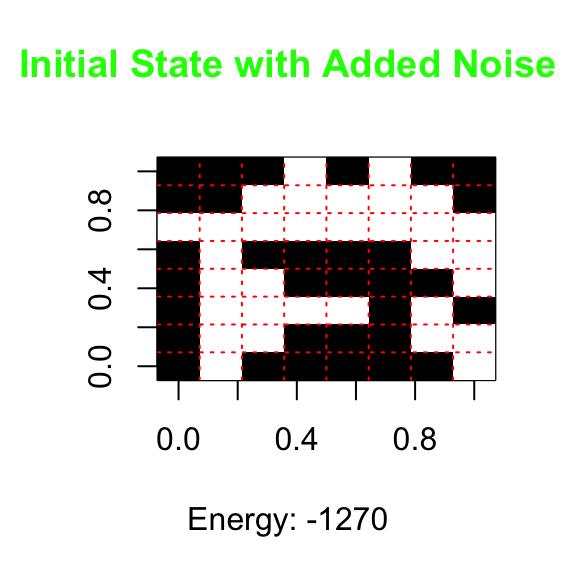

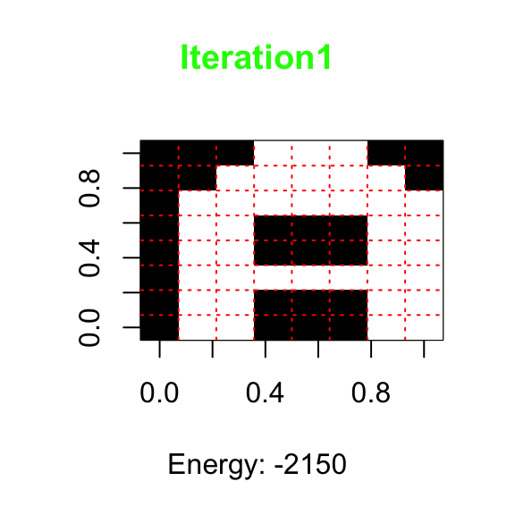

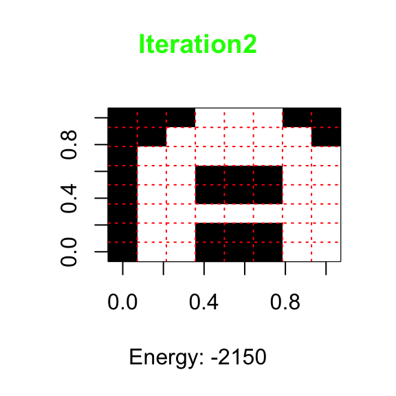

### Letter A with Sigma=1.5

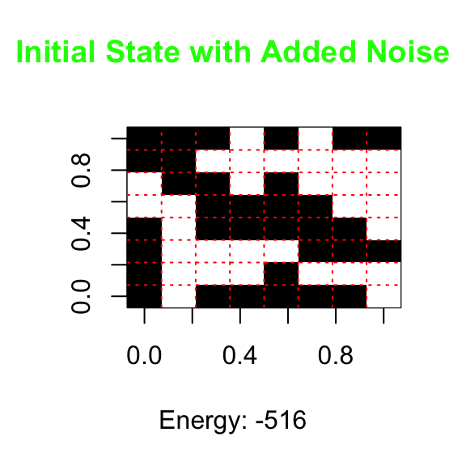

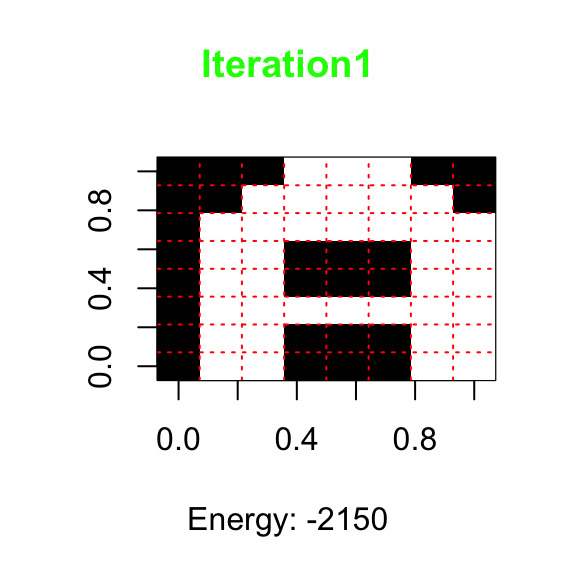

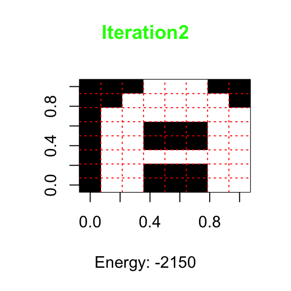

### Letter A with Sigma=2

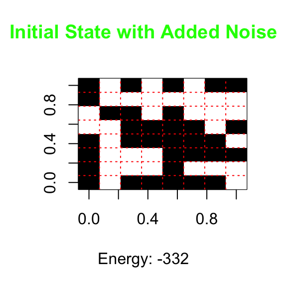

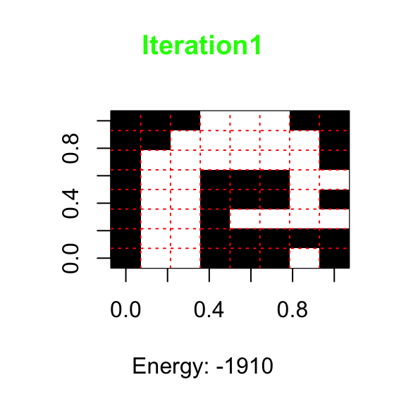

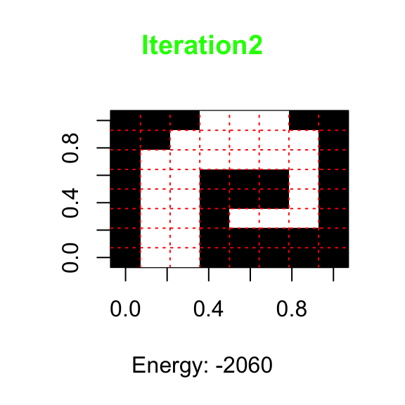

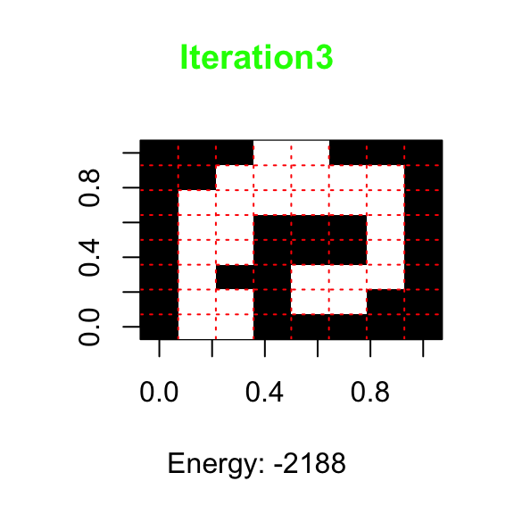

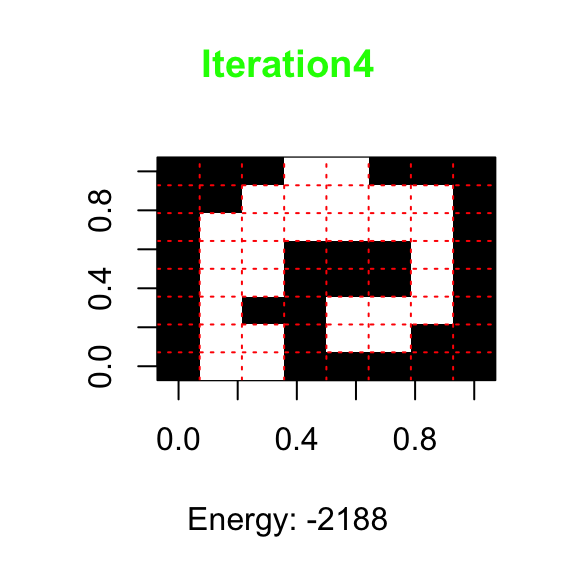

### Letter B with Sigma=1

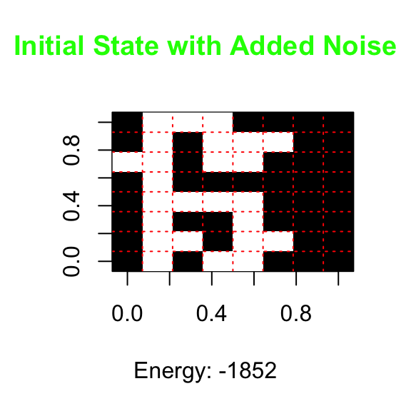

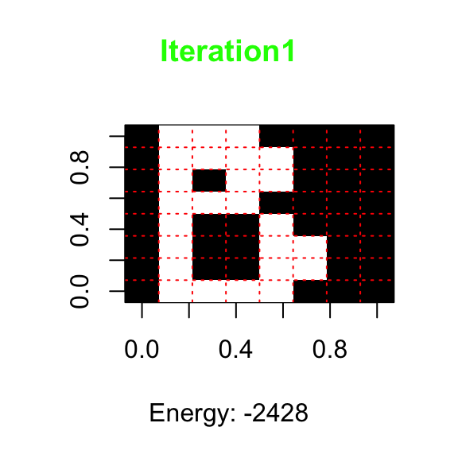

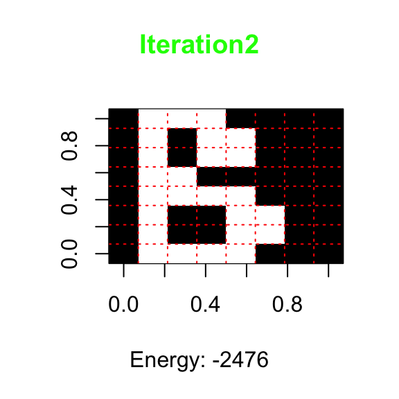

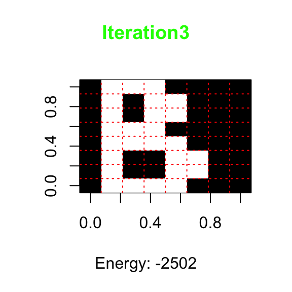

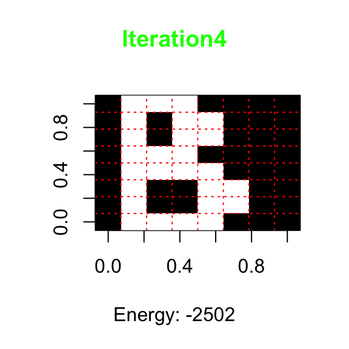

### Letter B with Sigma=1.5

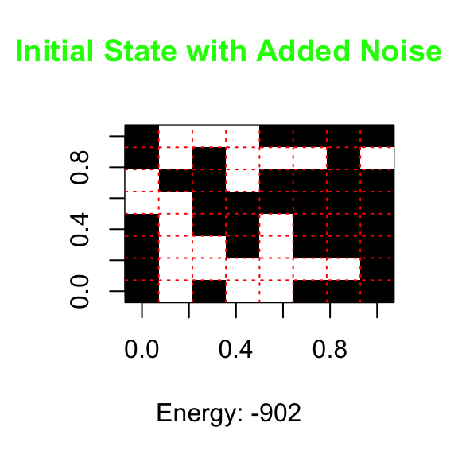

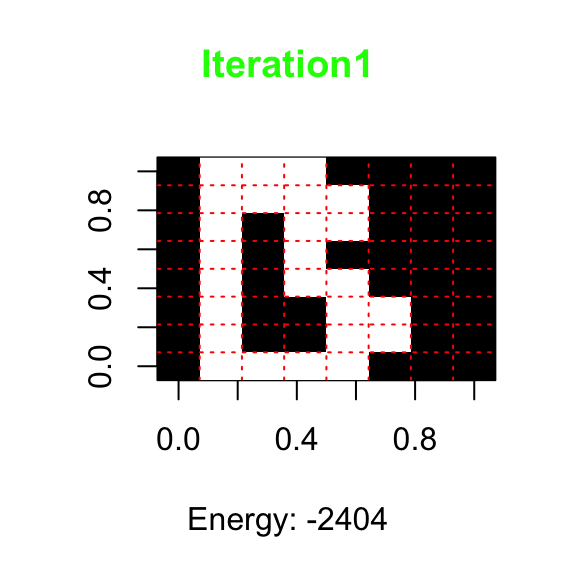

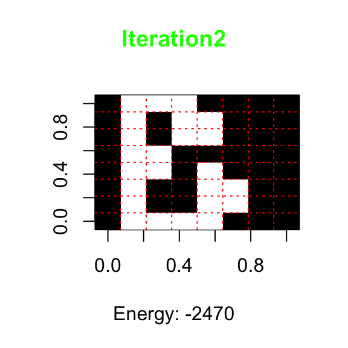

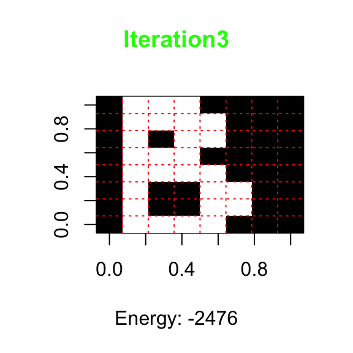

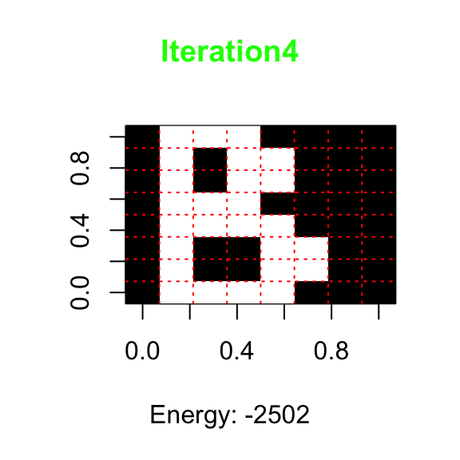

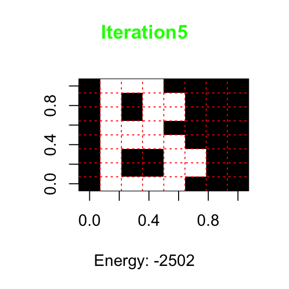

### Letter B with Sigma=2

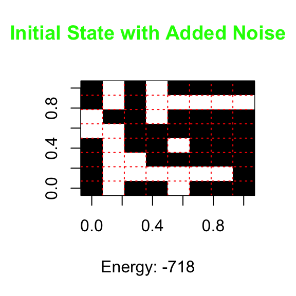

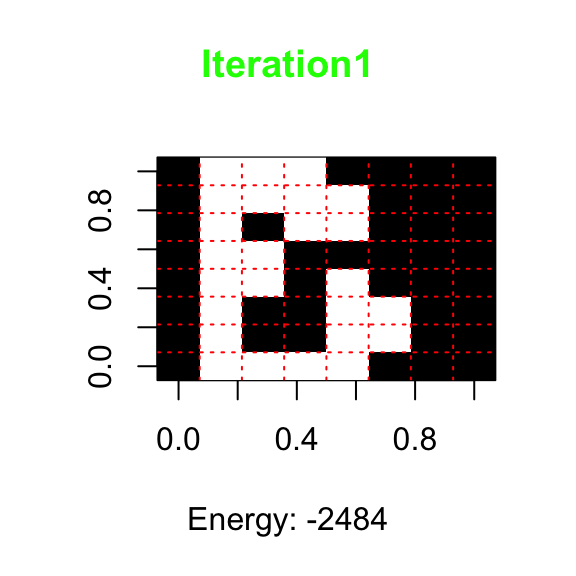

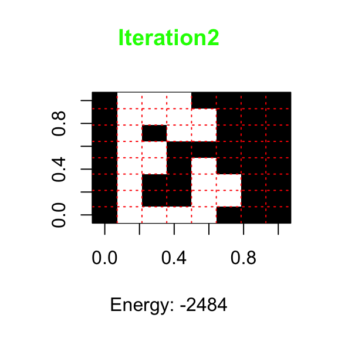

### Letter C with Sigma=1

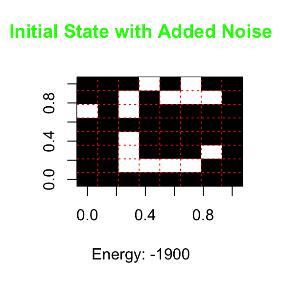

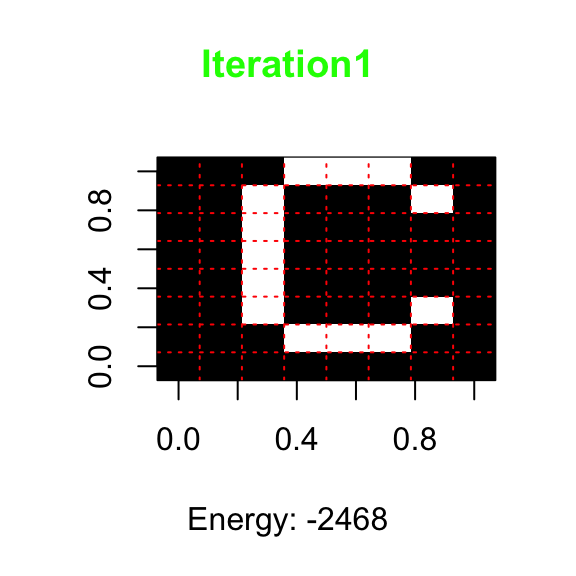